# Spatial Regression Analysis

Erin Schwarzbach

# 1 Ordinary Least Squares

First, we perform an ordinary least squares model to test the relationship between the childhood poverty level in Louisiana and all of the factors we have.

```
##      FIPS              State           County_Name          Longitude
##  Length:64          Length:64          Length:64          Min.   :-93.88
##  Class :character   Class :character   Class :character   1st Qu.:-92.64
##  Mode  :character   Mode  :character   Mode  :character   Median :-91.78
##                                                           Mean   :-91.82
##                                                           3rd Qu.:-91.05
##                                                           Max.   :-89.61
##     Latitude     child.pov.2016  unemployment_13    per_lhs_13
##  Min.   :29.44   Min.   : 8.40   Min.   : 4.900   Min.   :11.00
##  1st Qu.:30.21   1st Qu.:24.30   1st Qu.: 6.200   1st Qu.:16.50
##  Median :30.84   Median :29.25   Median : 7.350   Median :20.60
##  Mean   :31.10   Mean   :31.00   Mean   : 7.605   Mean   :21.07
##  3rd Qu.:32.10   3rd Qu.:36.45   3rd Qu.: 8.400   3rd Qu.:25.00
##  Max.   :32.84   Max.   :68.40   Max.   :16.800   Max.   :34.20
##   per_black_13    per_hispanic_13     per_ag_13      per_construction_13
##  Min.   : 1.679   Min.   : 0.2802   Min.   : 1.141   Min.   : 1.874
##  1st Qu.:19.346   1st Qu.: 1.6619   1st Qu.: 3.381   1st Qu.: 6.722
##  Median :30.584   Median : 2.5084   Median : 7.214   Median : 7.732
##  Mean   :31.682   Mean   : 3.0271   Mean   : 7.499   Mean   : 8.533
##  3rd Qu.:40.957   3rd Qu.: 3.9413   3rd Qu.:10.389   3rd Qu.: 9.817
##  Max.   :70.289   Max.   :12.7670   Max.   :22.090   Max.   :15.472
##  per_manufacturing_13 per_retail_13   per_healthss_13 per_singlemom_13
##  Min.   : 2.508       Min.   : 5.81   Min.   :14.99   Min.   : 2.001
##  1st Qu.: 6.662       1st Qu.:10.21   1st Qu.:21.04   1st Qu.:11.392
##  Median : 8.687       Median :11.52   Median :23.65   Median :13.228
##  Mean   : 9.147       Mean   :11.43   Mean   :23.78   Mean   :13.300
##  3rd Qu.:11.263       3rd Qu.:12.73   3rd Qu.:26.49   3rd Qu.:15.851
##  Max.   :25.143       Max.   :18.23   Max.   :35.75   Max.   :20.981
##      urban            rural           lnchildpov    lnunemployment
##  Min.   :0.0000   Min.   :0.00000   Min.   :2.128   Min.   :1.589
##  1st Qu.:0.0000   1st Qu.:0.00000   1st Qu.:3.190   1st Qu.:1.825
##  Median :1.0000   Median :0.00000   Median :3.376   Median :1.995
##  Mean   :0.5469   Mean   :0.07812   Mean   :3.376   Mean   :1.998
##  3rd Qu.:1.0000   3rd Qu.:0.00000   3rd Qu.:3.596   3rd Qu.:2.128
##  Max.   :1.0000   Max.   :1.00000   Max.   :4.225   Max.   :2.821
##     lnlesshs        lnblack         lnhispanic           lnag
##  Min.   :2.398   Min.   :0.5183   Min.   :-1.2721   Min.   :0.1323
##  1st Qu.:2.803   1st Qu.:2.9624   1st Qu.: 0.5079   1st Qu.:1.2181
##  Median :3.025   Median :3.4204   Median : 0.9196   Median :1.9760
##  Mean   :3.013   Mean   :3.3169   Mean   : 0.8955   Mean   :1.7330
```

[output cut: 8 more lines]

```
##  Max.   :2.739   Max.   :3.2246   Max.   :2.903   Max.   :3.577
##   lnsinglemom       lnchpov17      lnuninsured    lnincome_ratio
##  Min.   :0.6937   Min.   :2.067   Min.   :2.704   Min.   :1.333
##  1st Qu.:2.4329   1st Qu.:3.180   1st Qu.:2.922   1st Qu.:1.602
##  Median :2.5823   Median :3.321   Median :3.000   Median :1.665
##  Mean   :2.5421   Mean   :3.371   Mean   :2.984   Mean   :1.661
##  3rd Qu.:2.7632   3rd Qu.:3.612   3rd Qu.:3.046   3rd Qu.:1.729
##  Max.   :3.0436   Max.   :4.337   Max.   :3.194   Max.   :2.041
##  lnsevere_housing  lnteenbirth     lnunmarried
##  Min.   :1.998    Min.   :2.969   Min.   :2.595
##  1st Qu.:2.511    1st Qu.:3.789   1st Qu.:3.597
##  Median :2.618    Median :4.043   Median :3.851
##  Mean   :2.619    Mean   :3.956   Mean   :3.794
##  3rd Qu.:2.749    3rd Qu.:4.183   3rd Qu.:4.063
##  Max.   :3.365    Max.   :4.418   Max.   :4.382
```

```
##
## Call:
## lm(formula = equation, data = la_pov)
##
## Residuals:
##     Min      1Q  Median      3Q     Max
## -9.0233 -3.0907 -0.5661  3.2065 12.8167
##
## Coefficients:
##                 Estimate Std. Error t value  Pr(>|t|)
## (Intercept)     -91.1818    37.1617  -2.454    0.0179 *
## rural            -4.1880     3.4297  -1.221    0.2281
## urban             0.1804     2.0287   0.089    0.9295
## lnmanufacturing   0.1976     2.4137   0.082    0.9351
## lnag              0.7968     1.8163   0.439    0.6629
## lnretail         -3.4880     5.4036  -0.645    0.5217
## lnhealthss        6.1262     6.4516   0.950    0.3472
## lnconstruction   -7.7853     3.4532  -2.254    0.0289 *
## lnlesshs          8.7521     4.7194   1.855    0.0699 .
## lnunemployment   23.0403     5.3020   4.346 0.0000738 ***
## lnsinglemom       2.4115     4.0740   0.592    0.5567
## lnblack           1.1413     2.7748   0.411    0.6827
## lnhispanic        0.2240     1.5382   0.146    0.8848
## lnuninsured       5.0504     9.8358   0.513    0.6100
## lnincome_ratio    5.7726     8.5035   0.679    0.5006
## lnteenbirth       3.1657     2.3815   1.329    0.1902
## lnunmarried       1.6645     2.7654   0.602    0.5501
## ---
## Signif. codes:  0 '***' 0.001 '**' 0.01 '*' 0.05 '.' 0.1 ' ' 1
##
## Residual standard error: 5.633 on 47 degrees of freedom
## Multiple R-squared:  0.7867, Adjusted R-squared:  0.714
## F-statistic: 10.83 on 16 and 47 DF,  p-value: 7.999e-11
```

From the OLS we can see that construction and unemployment are the two factors that are significant in this relationship.

# 2 Spatial Analysis Regression - Contiguity

Next, we can begin our spatial analysis regression by making a list of contiguity neighbors. We will use FIPS to do this, and use the Queens Case because it allows us to have neighbors created from lines and points.

```
##
##  Global Moran I for regression residuals
##
## data:
## model: lm(formula = equation, data = la_pov)
## weights: cont.neighb
##
## Moran I statistic standard deviate = 0.24638, p-value = 0.4027
## alternative hypothesis: greater
## sample estimates:
## Observed Moran I      Expectation         Variance
##     -0.040540057     -0.058515039      0.005322795
```

## 2.1 LaGrange Multipliers Test

```r
lm.LMtests(ols, cont.neighb, test="all")
```

```
##
##  Lagrange multiplier diagnostics for spatial dependence
##
## data:
## model: lm(formula = equation, data = la_pov)
## weights: cont.neighb
##
## LMerr = 0.2348, df = 1, p-value = 0.628
##
##
##  Lagrange multiplier diagnostics for spatial dependence
##
## data:
## model: lm(formula = equation, data = la_pov)
## weights: cont.neighb
##
## LMlag = 5.7456, df = 1, p-value = 0.01653
##
##
##  Lagrange multiplier diagnostics for spatial dependence
##
## data:
## model: lm(formula = equation, data = la_pov)
## weights: cont.neighb
##
## RLMerr = 6.6391, df = 1, p-value = 0.009977
##
##
##  Lagrange multiplier diagnostics for spatial dependence
##
## data:
## model: lm(formula = equation, data = la_pov)
## weights: cont.neighb
##
## RLMlag = 12.15, df = 1, p-value = 0.0004909
##
##
##  Lagrange multiplier diagnostics for spatial dependence
##
## data:
## model: lm(formula = equation, data = la_pov)
## weights: cont.neighb
##
## SARMA = 12.385, df = 2, p-value = 0.002045
```

Because the p-value is not significant, this means that a spatial model may not be the best fit for this data. BUT because this is the assignment and we’re looking at spatial regressions, let’s do one anyways. Looking at the different models, the one that is most significant for this data is the RMLlag. Therefore, let’s run a spatial lag model.

## 2.2 Spatial Lag Model

```
##
## Call:
## spatialreg::lagsarlm(formula = equation, data = la_pov, listw = cont.neighb)
##
## Residuals:
##       Min        1Q    Median        3Q       Max
## -10.24655  -2.93784  -0.02863   3.25599  10.32183
##
## Type: lag
## Coefficients: (asymptotic standard errors)
##                   Estimate Std. Error z value   Pr(>|z|)
## (Intercept)     -78.501316  30.349144 -2.5866   0.009693
## rural            -5.779278   2.826406 -2.0447   0.040880
## urban            -0.038449   1.641932 -0.0234   0.981318
## lnmanufacturing   0.094802   1.959164  0.0484   0.961406
## lnag              0.451975   1.512021  0.2989   0.765000
## lnretail         -2.496775   4.374330 -0.5708   0.568150
## lnhealthss        2.752781   5.451190  0.5050   0.613568
## lnconstruction   -6.210711   2.818123 -2.2038   0.027535
## lnlesshs          8.637579   3.820833  2.2607   0.023781
## lnunemployment   19.570124   4.451967  4.3958 0.00001103
## lnsinglemom       2.528462   3.297174  0.7669   0.443166
## lnblack           1.163786   2.244906  0.5184   0.604171
## lnhispanic        0.056228   1.250454  0.0450   0.964134
## lnuninsured       0.784888   8.004704  0.0981   0.921890
## lnincome_ratio    8.170723   6.968775  1.1725   0.241006
## lnteenbirth       2.876471   1.926835  1.4928   0.135477
## lnunmarried       2.042060   2.242698  0.9105   0.362539
##
## Rho: 0.28623, LR test value: 6.152, p-value: 0.013127
## Asymptotic standard error: 0.1054
##     z-value: 2.7157, p-value: 0.0066136
## Wald statistic: 7.375, p-value: 0.0066136
##
## Log likelihood: -188.4943 for lag model
## ML residual variance (sigma squared): 20.77, (sigma: 4.5574)
## Nagelkerke pseudo-R-squared: 0.80621
## Number of observations: 64
## Number of parameters estimated: 19
## AIC: 414.99, (AIC for lm: 419.14)
## LM test for residual autocorrelation
## test value: 5.2605, p-value: 0.021814
```

Now that we have the summary from this test, let’s look at the impact table.

```
##                        Direct  Indirect         Total
## rural           0.03622066130 0.2016628 0.05681263554
## urban           0.91980582061 0.9052675 0.91425973276
## lnmanufacturing 0.94699615022 0.9589787 0.94968197956
## lnag            0.80214343371 0.9310963 0.83670731380
## lnretail        0.45921663813 0.5429096 0.47037751605
## lnhealthss      0.62741627765 0.7754080 0.66506580779
## lnconstruction  0.03714856150 0.1687851 0.04860294661
## lnlesshs        0.00987902658 0.1536873 0.02193517788
## lnunemployment  0.00001933567 0.0467086 0.00004287807
## lnsinglemom     0.33624337908 0.4594384 0.35201646685
## lnblack         0.75389091661 0.8181867 0.76710295280
## lnhispanic      0.86954854775 0.9889865 0.90509679747
## lnuninsured     0.80635956718 0.8742008 0.82384572456
## lnincome_ratio  0.27034168054 0.3870019 0.28850394292
## lnteenbirth     0.14493805265 0.2408839 0.14639073479
## lnunmarried     0.37257757885 0.4635493 0.38383944621
```

# 3 Spatial Regression Analysis using K Nearest Neighbors

Now that we have a distance lag model created, we can use the summary function to look at the K=1 lag model.

## 3.1 Distance lag model for K=1

```
##
## Call:spatialreg::lagsarlm(formula = formula, data = data, listw = listw,
##     na.action = na.action, Durbin = Durbin, type = type, method = method,
##     quiet = quiet, zero.policy = zero.policy, interval = interval,
##     tol.solve = tol.solve, trs = trs, control = control)
##
## Residuals:
##     Min      1Q  Median      3Q     Max
## -9.7289 -2.9400 -0.6202  3.5767 12.4153
##
## Type: lag
## Coefficients: (asymptotic standard errors)
##                   Estimate Std. Error z value    Pr(>|z|)
## (Intercept)     -82.136668  31.282439 -2.6256    0.008648
## rural            -5.813008   2.970521 -1.9569    0.050359
## urban             0.159832   1.696268  0.0942    0.924930
## lnmanufacturing  -0.076266   2.038203 -0.0374    0.970151
## lnag              0.548820   1.534138  0.3577    0.720539
## lnretail         -2.620789   4.520722 -0.5797    0.562098
## lnhealthss        4.011689   5.509612  0.7281    0.466537
## lnconstruction   -6.898995   2.901459 -2.3778    0.017418
## lnlesshs          9.115179   3.944742  2.3107    0.020849
## lnunemployment   20.724129   4.507279  4.5979 0.000004267
## lnsinglemom       2.227171   3.437541  0.6479    0.517052
## lnblack           1.464260   2.332673  0.6277    0.530189
## lnhispanic        0.080261   1.283725  0.0625    0.950147
## lnuninsured       2.061637   8.288895  0.2487    0.803575
## lnincome_ratio    7.201000   7.127878  1.0103    0.312371
## lnteenbirth       2.944548   1.987632  1.4814    0.138491
## lnunmarried       1.674996   2.307888  0.7258    0.467980
##
## Rho: 0.17336, LR test value: 2.754, p-value: 0.097013
## Asymptotic standard error: 0.094283
##     z-value: 1.8387, p-value: 0.065954
## Wald statistic: 3.3809, p-value: 0.065954
##
## Log likelihood: -190.1933 for lag model
## ML residual variance (sigma squared): 22.103, (sigma: 4.7014)
## Nagelkerke pseudo-R-squared: 0.79565
## Number of observations: 64
## Number of parameters estimated: 19
## AIC: 418.39, (AIC for lm: 419.14)
## LM test for residual autocorrelation
## test value: 4.5335, p-value: 0.033238
```

We can also create a distance error model and look at the summary table for K=1.

## 3.2 Distance error model for K=1

```
##
## Call:
## spatialreg::errorsarlm(formula = formula, data = data, listw = listw,
##     na.action = na.action, Durbin = Durbin, etype = etype, method = method,
##     quiet = quiet, zero.policy = zero.policy, interval = interval,
##     tol.solve = tol.solve, trs = trs, control = control)
##
## Residuals:
##      Min       1Q   Median       3Q      Max
## -7.45517 -3.42581 -0.36329  3.00410 10.54596
##
## Type: error
## Coefficients: (asymptotic standard errors)
##                   Estimate Std. Error z value  Pr(>|z|)
## (Intercept)     -116.47708   27.90162 -4.1746 2.986e-05
## rural             -2.19353    3.17336 -0.6912   0.48942
## urban              1.74719    1.51796  1.1510   0.24973
## lnmanufacturing   -0.70816    1.79597 -0.3943   0.69336
## lnag               0.11191    1.24118  0.0902   0.92816
## lnretail          -5.80661    4.11740 -1.4103   0.15846
## lnhealthss         6.31705    4.45882  1.4168   0.15655
## lnconstruction    -9.14294    2.82689 -3.2343   0.00122
## lnlesshs           8.95714    3.36714  2.6602   0.00781
## lnunemployment    27.29043    3.90385  6.9906 2.736e-12
## lnsinglemom       -1.59948    3.30684 -0.4837   0.62861
## lnblack            2.19331    2.15019  1.0201   0.30770
## lnhispanic         1.46632    1.19466  1.2274   0.21967
## lnuninsured       11.31248    7.59588  1.4893   0.13641
## lnincome_ratio     9.40301    6.50709  1.4450   0.14845
## lnteenbirth        4.86530    1.99618  2.4373   0.01480
## lnunmarried        1.72641    2.24152  0.7702   0.44118
##
## Lambda: -0.50988, LR test value: 4.6758, p-value: 0.03059
## Asymptotic standard error: 0.12705
##     z-value: -4.0134, p-value: 0.000059851
## Wald statistic: 16.107, p-value: 0.000059851
##
## Log likelihood: -189.2324 for error model
## ML residual variance (sigma squared): 19.853, (sigma: 4.4556)
## Nagelkerke pseudo-R-squared: 0.80169
## Number of observations: 64
## Number of parameters estimated: 19
## AIC: 416.46, (AIC for lm: 419.14)
```

# 4 Creating a map of the results

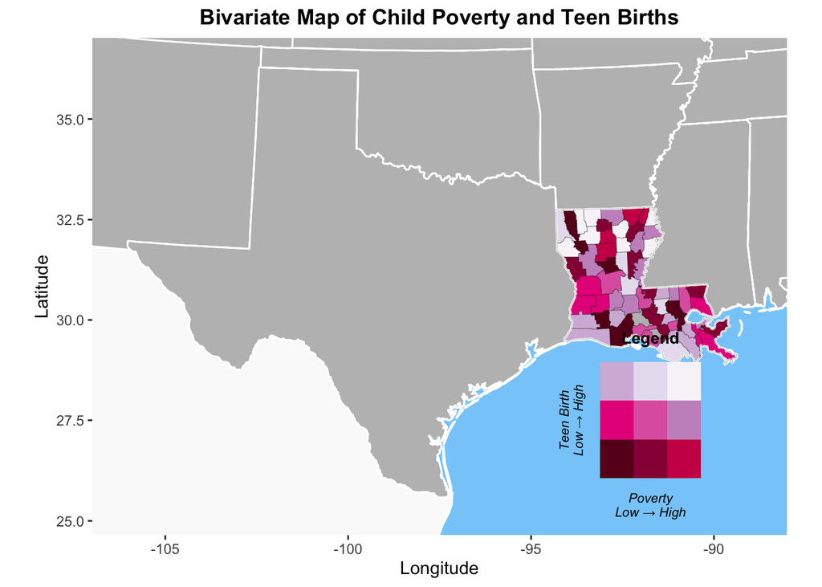